# DATA 550 - Lab 1 - Visualizing world health data

# 5. Carbon dioxide emissions

CO2 emissions are often talked about in it's relation to climate change. Let's explore the data to see which countries emits the most CO2 per capita and which regions has emitted the most in total over time.

### Question 5.1

rubric={accuracy:1,quality:1,viz:2}

#### Python

1. Filter the data to include only the most recent year when `'co2_per_capita'` was measured (it is up to you how you find out which year this is).
2. Use the data frame `nlargest` method to select the top 40 countries in CO2 production per capita for that year.
3. Since we have only one value per country per year, let’s create a bar chart to visualize it. Encode the CO2 per capita as on the x-axis, the country on the y-axis, and the region as the color.
4. Sort your bar chart so that the highest CO2 per capita is the closest to the x-axis (the bottom of the chart). [Here is an example of how to sort in Altair](https://altair-viz.github.io/gallery/bar_chart_sorted.html).

```python
import pandas as pd
import altair as alt

# Find the most recent year with 'co2_per_capita' data
most_recent_co2_year = data.dropna(subset=['co2_per_capita'])['year'].max()

# Filter data for the most recent year
co2_data_recent_year = data[data['year'] == most_recent_co2_year]
top_40_co2 = co2_data_recent_year.nlargest(40, 'co2_per_capita')

chart = alt.Chart(top_40_co2).mark_bar().encode(
    x=alt.X('co2_per_capita:Q', title='CO2 per Capita'),
    y=alt.Y('country:N', sort='-x', title='Country'),
    color=alt.Color('region:N', title='Region')
).properties(
    title=f'Top 40 Countries by CO2 per Capita in {most_recent_co2_year}'
)

chart
```

[interactive chart not shown]

### Question 5.2

rubric={accuracy:1,quality:1,viz:2}

#### R

1. Filter the data to include only the most recent year when `'co2_per_capita'` was measured (it is up to you how you find out which year this is).
2. Use the `slice_max` function from dplyr to select the top 40 countries in CO2 production per capita for that year.
3. Since we have only one value per country per year, let’s create a bar chart to visualize it. Set the aesthetics so that the CO2 per capita is on the x-axis, the country is on the y-axis, and the region is the color (you can use `fill` instead of `color` to get rid of the black outlines).
4. Sort your bar chart so that the highest CO2 per capita is the closest to the x-axis (the bottom of the chart). [Here is an example of how to sort in ggplot using the base R function `reorder`](https://stackoverflow.com/questions/25664007/reorder-bars-in-geom-bar-ggplot2-by-value).

See [this SO answer](https://stackoverflow.com/a/59009108/2166823) if you are having issues creating the bar chart.

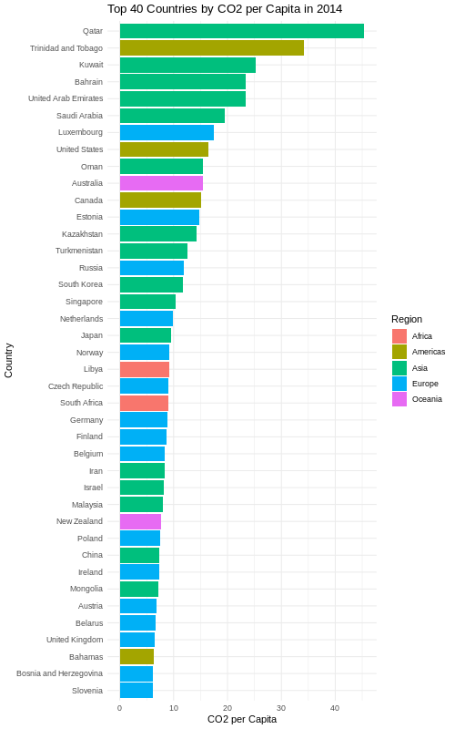

```python
%%R -w 500 -h 800
library(readr)
library(dplyr)
library(ggplot2)

gapminder_df <- read_csv(
  "https://raw.githubusercontent.com/UofTCoders/workshops-dc-py/master/data/processed/world-data-gapminder.csv"
)

most_recent_co2_year <- gapminder_df %>%
  filter(!is.na(co2_per_capita)) %>%
  pull(year) %>%
  max()

top_40_co2 <- gapminder_df %>%
  filter(year == most_recent_co2_year) %>%
  arrange(desc(co2_per_capita)) %>%
  slice_head(n = 40)

# Create the bar chart
ggplot(top_40_co2, aes(
    x = co2_per_capita,
    y = reorder(country, co2_per_capita),
    fill = region
  )) +
  geom_col() +
  labs(
    x = "CO2 per Capita",
    y = "Country",
    fill = "Region",
    title = paste("Top 40 Countries by CO2 per Capita in", most_recent_co2_year)
  ) +
  theme_minimal()
```

### Question 5.3

rubric={accuracy:1,quality:1,viz:2}

#### Python

1. in addition to the co2 per capita, the total population also matter for a country’s overall co2 emissions. compute a new column in your data set called `'co2_total'` which contains the total co2 emissions per observation.
2. plot this new column over time in an area chart, but instead of plotting one area for each country, plot one for each region which represents the sum of all countries co2 emissions in that region.

```python
data['co2_total']=data['co2_per_capita']*data['population']
co2_by_region=data.groupby(['year','region'])['co2_total'].sum().reset_index()
# print(co2_by_region)
chart=alt.Chart(co2_by_region).mark_area(opacity=0.3).encode(
    x='year',
    y='co2_total',
    color='region')
chart
```

[interactive chart not shown]

### Question 5.4

rubric={accuracy:1,quality:1,viz:2}

#### R

1. in addition to the co2 per capita, the total population also matter for a country’s overall co2 emissions. compute a new column in your data set called `'co2_total'` which contains the total co2 emissions per observation.
2. plot this new column over time in an area chart, but instead of plotting one area for each country, plot one for each region which represents the sum of all countries co2 emissions in that region. In order for the areas to stack, you will have to set `position='stack'`.

[See this link if you want to read some background info on on when to use `geom_*` and when to use `stat_summary()`](https://stackoverflow.com/a/44226841/2166823)

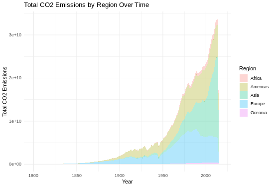

```python
%%R -w 550 -h 375
library(readr)
library(dplyr)
library(ggplot2)

# Load the Gapminder data
gapminder_df <- read_csv(
  "https://raw.githubusercontent.com/UofTCoders/workshops-dc-py/master/data/processed/world-data-gapminder.csv"
)

# 1. Compute a new column 'co2_total'
gapminder_df <- gapminder_df %>%
  mutate(co2_total = co2_per_capita * population)

# Aggregate 'co2_total' by 'year' and 'region'
co2_by_region <- gapminder_df %>%
  group_by(year, region) %>%
  summarize(co2_total = sum(co2_total, na.rm = TRUE), .groups = 'drop')

# 2. Plot 'co2_total' over time in an area chart for each region
ggplot(co2_by_region, aes(
    x = year,
    y = co2_total,
    fill = region
  )) +
  geom_area(alpha = 0.3, position = 'stack') + # position='stack' to layer areas
  labs(
    x = "Year",
    y = "Total CO2 Emissions",
    fill = "Region",
    title = "Total CO2 Emissions by Region Over Time"
  ) +
  theme_minimal()
```

# 6. Income distribution

In his talk back in 2003, Rosling showed a projection of how the world income distribution would look like in 2015. Let’s eyeball if the suggested trend was accurate.

### Question 6.1 (Optional)

rubric={accuracy:1,viz:1}

#### Python

1. Wrangle your data to include the years 1979, 1991, 2003 and 2015.
2. Create a histogram (binned bar chart) of the income distribution with an appropriate number of bins.
3. Facet by year and make the plots smaller so that they fit in a single row.
4. It is a little hard to tell if the data is exactly the same as the prediction since we are not using a log scale and a histogram instead of a density plot (we’ll learn about these things later). But in general, briefly explain whether you think the trend is the same or not?

I think the trend overall is the same

```python
import altair as alt
import pandas as pd

# 1. Wrangle data to include specific years
specific_years = [1979, 1991, 2003, 2015]
income_data_filtered = data[data['year'].isin(specific_years)]

# 2. Create a histogram of the income distribution
# 3. Facet by year and make plots smaller
chart = alt.Chart(income_data_filtered).mark_bar().encode(
    alt.X('income:Q', bin=alt.Bin(maxbins=50), title='Income (GDP per capita)'),
    alt.Y('count():Q', title='Number of Countries'),
    # Facet by year and lay out in a single row
    column=alt.Column('year:O', header=alt.Header(titleOrient="bottom", labelOrient="bottom"))
).properties(
    title='Income Distribution by Year'
).resolve_scale(x='independent') # Allow x-axis scales to be independent for better visibility

chart
```

[interactive chart not shown]

### Question 6.2 (Optional)

rubric={accuracy:1,viz:1}

#### R

1. Wrangle your data to include the years 1979, 1991, 2003 and 2015.
2. Create a histogram (binned bar chart) of the income distribution with an appropriate number of bins.
3. Facet by year and make the plots smaller so that they fit in a single row.
4. It is a little hard to tell if the data is exactly the same as the prediction since we are not using a log scale and a histogram instead of a density plot (we’ll learn about these things later). But in general, briefly explain whether you think the trend is the same or not?

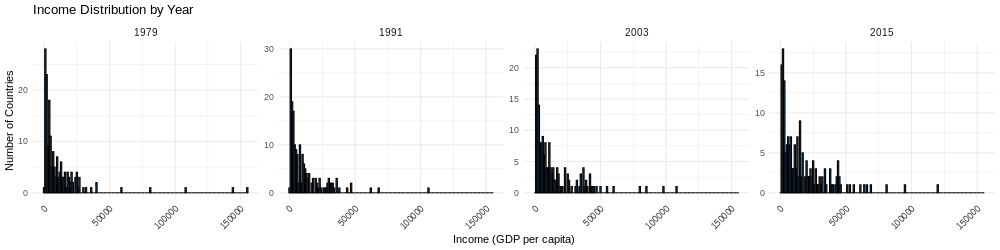

```python
%%R -w 1000 -h 250
library(readr)
library(dplyr)
library(ggplot2)

# Load the Gapminder data
gapminder_df <- read_csv(
  "https://raw.githubusercontent.com/UofTCoders/workshops-dc-py/master/data/processed/world-data-gapminder.csv"
)

# 1. Wrangle data to include specific years
specific_years <- c(1979, 1991, 2003, 2015)
income_data_filtered <- gapminder_df %>%
  filter(year %in% specific_years)

# 2. Create a histogram of the income distribution
# 3. Facet by year and make plots smaller
ggplot(income_data_filtered, aes(x = income)) +
  geom_histogram(binwidth = 1000, fill = "steelblue", color = "black") +
  facet_wrap(~ year, ncol = 4, scales = "free_y") + # Facet by year in a single row
  labs(
    x = "Income (GDP per capita)",
    y = "Number of Countries",
    title = "Income Distribution by Year"
  ) +
  theme_minimal() +
  theme(axis.text.x = element_text(angle = 45, hjust = 1), # Rotate x-axis labels
        strip.text = element_text(size = 10)) # Make facet titles smaller
```

# 7. Chart beautification

Let's make our charts from question 2 look more like the Gapminder bubble chart! Beautifying charts can take a long time, but it is also satisfying when you end up with a really nice looking chart in the end. We will learn more about how to create charts for communication later, but these parameters are usually enough to create basic communication charts and to help you in your data exploration.

### Question 7.1

rubric={accuracy:2,quality:1,viz:1}

#### Python

1. Copy in your code from question 2.1 and confirm that your scatter plot is generated properly so that you didn't miss to copy anything.
2. Add a title of your choice to the chart.
3. Set the x-axis and y-axis scale so that they don’t include zero and are zoomed in to the extent of the data instead.
4. Set proper titles for the axis and the legends, which include spaces instead of underscores and are capitalized.
5. Some of the dots are really hard to see because they are so small and it is a bit difficult to distinguish the changes in size as well. Let’s make everything bigger and emphasize the size difference by using the [range argument to `alt.Scale`](https://altair-viz.github.io/gallery/airport_connections.html) (there is a lot of other things going on in this example, so just focus on how they specify `size`).
6. Enlarge the axis title font by finding and setting the [right parameter of `.configure_axis`](https://altair-viz.github.io/user_guide/configuration.html?highlight=titlefont#axis-configuration)

```python
import pandas as pd
import altair as alt
data=pd.read_csv("https://raw.githubusercontent.com/UofTCoders/workshops-dc-py/master/data/processed/world-data-gapminder.csv")

filter_year=data['year']==1962
data_ByYear=data[filter_year]

alt.Chart(data_ByYear).mark_circle().encode(
    y = alt.Y('life_expectancy:Q', title='Life Expectancy', scale=alt.Scale(zero=False)),
    x = alt.X('children_per_woman:Q', title='Children Per Woman', scale=alt.Scale(zero=False)),
    size=alt.Size('population:Q', title='Population', scale=alt.Scale(range=[100, 1000]))
    color=alt.Color('region:N', title='Region')
).properties(
    title='Global Health Trends in 1962'
).configure_axis(
    titleFontSize=14
)
```

[interactive chart not shown]

### Question 7.2

rubric={accuracy:2,quality:1,viz:1}

#### R

1. Copy in your code from question 2.2 and confirm that your scatter plot is generated properly so that you didn't miss to copy anything.
2. Add a title of your choice to the chart.
3. Set the [transparency of the points](https://ggplot2.tidyverse.org/reference/geom_point.html) to an appropriate value, so that they are not completely obfuscating each other.
4. Set proper titles for the axis and the legends, which include spaces instead of underscores and are capitalized.
5. Change to a black and white theme.
6. Enlarge the text for all fonts ([See here if you need guidance)](https://stackoverflow.com/a/34528522/2166823).
7. Some of the dots are really hard to see because they are so small and it is a bit difficult to distinguish the changes in size as well. Let’s make everything bigger and emphasize the size difference by using the [`scale_size` function.](https://ggplot2.tidyverse.org/reference/scale_size.html)

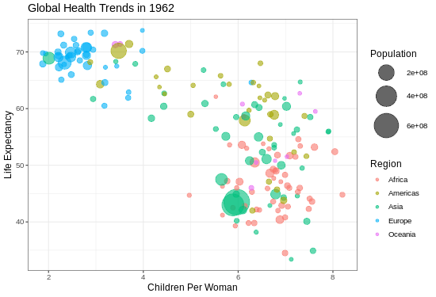

```python
%%R -w 550 -h 375
library(readr)
library(dplyr)
library(ggplot2)

# Load 2018 Gapminder-style data directly from the URL
gapminder_df <- read_csv("https://raw.githubusercontent.com/UofTCoders/workshops-dc-py/master/data/processed/world-data-gapminder.csv")

# Bubble chart for a single year (1962)
gapminder_df %>%
  filter(year == "1962") %>%
  ggplot(aes(
    x = children_per_woman,
    y = life_expectancy,
    color = region,
    size = population
  )) +
  geom_point(alpha = 0.6) + #
  scale_size_continuous(range = c(2, 15)) +
  labs(
    title = "Global Health Trends in 1962", # Add the title
    x = "Children Per Woman", # Proper x-axis title
    y = "Life Expectancy", # Proper y-axis title
    color = "Region", # Proper color legend title
    size = "Population" # Proper size legend title
  ) +
  theme_bw() +
  theme(text = element_text(size = 12))
```